# Cabbages

Abel Jacobo Perez!

09/07/21

# Introduction

The cabbages data from the MASS package is loaded into a dataframe called veggy. Complete this report by answering the following two questions

### Is there a difference in average VitC between c39 and c52 cultivation methods?

$h_0$: there is no difference in the vitamin C content of cabbages cultivated with methods c39 and c52.

$h_A$: there is a difference between the vitamin c content of cabbages cultivated with methods c39 and c52

# Methods

VitC is a numerical variable. Cult is a categorical variable. So the helper file we need is numberical~cat

# Results

## Descriptive Results

### Graphical Descriptive Results

```r
basicCN <- ggplot(veggy,aes(x=Cult,y=VitC))
```

## Now add in boxplot

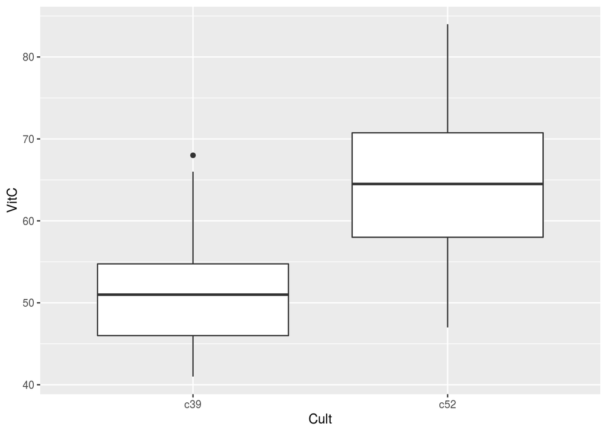

```r
basicCN + geom_boxplot()
```

### get fancy

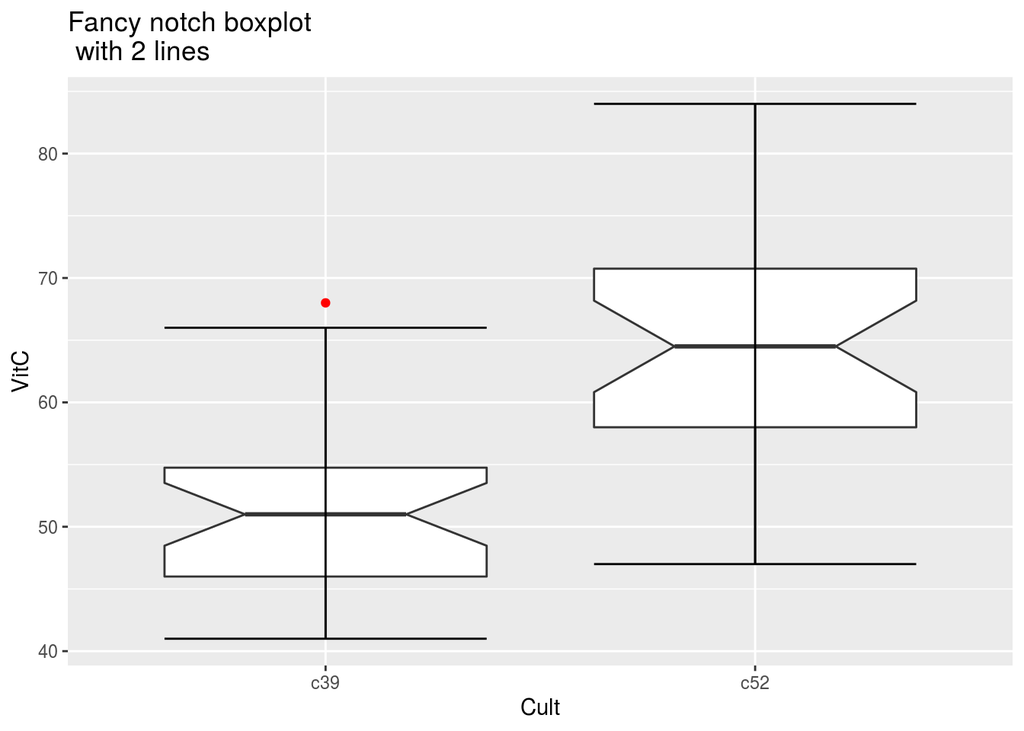

```r
basicCN + geom_boxplot(notch=TRUE,outlier.color = "red") + stat_boxplot(geom ='errorbar') + labs(title="Fancy notch boxplot \n with 2 lines")
```

### Numerical Descriptive Results

```r
favstats(VitC~Cult,data=veggy)
```

| Cult | min | Q1 | median | Q3 | max | mean | sd | n | missing |
| --- | --- | --- | --- | --- | --- | --- | --- | --- | --- |
| c39 | 41 | 46 | 51.0 | 54.75 | 68 | 51.5 | 7.123298 | 30 | 0 |
| c52 | 47 | 58 | 64.5 | 70.75 | 84 | 64.4 | 8.455156 | 30 | 0 |

```r
t.test(VitC~Cult,data=veggy)
```

```
##
##  Welch Two Sample t-test
##
## data:  VitC by Cult
## t = -6.3909, df = 56.376, p-value = 3.405e-08
## alternative hypothesis: true difference in means between group c39 and group c52 is not equal to 0
## 95 percent confidence interval:
##  -16.94296  -8.85704
## sample estimates:
## mean in group c39 mean in group c52
##              51.5              64.4
```

# Discussion and Conclusion

I reject the null hypothesis because the P value is way to low below the threshold. The vitamin C content of the cabbages cultivated with methods c39 and c52 are significantly different . The graphical descriptive results show that cabbages grown with method c39 have vitamin c levels at 45-55 while cabbages grown with method c52 have higher vitamin levels on average ,at 58-71.The numerical descriptive results show that the average vitamen C levels of cabbages grown with method c39 have and average vitamin C level of 51.5 while the c52 group had an average level of vitamn C at 64.4 .